# StatComp Project 1: 3D printer materials estimation

Boshu Jiang (s2196886)

```r
# Discover the name of the variable
ls(filament1)
```

```
## [1] "Actual_Weight" "CAD_Weight"    "Date"          "Index"
## [5] "Material"
```

We load the data and check our variables. There are 86 observations and 5 variables in the data frame filament1, which are “Actual_Weight” “CAD_Weight”“Date”“Index” and “Material”. Now, we will explore the variability of the data for different “CAD_Weight” and “Material”.

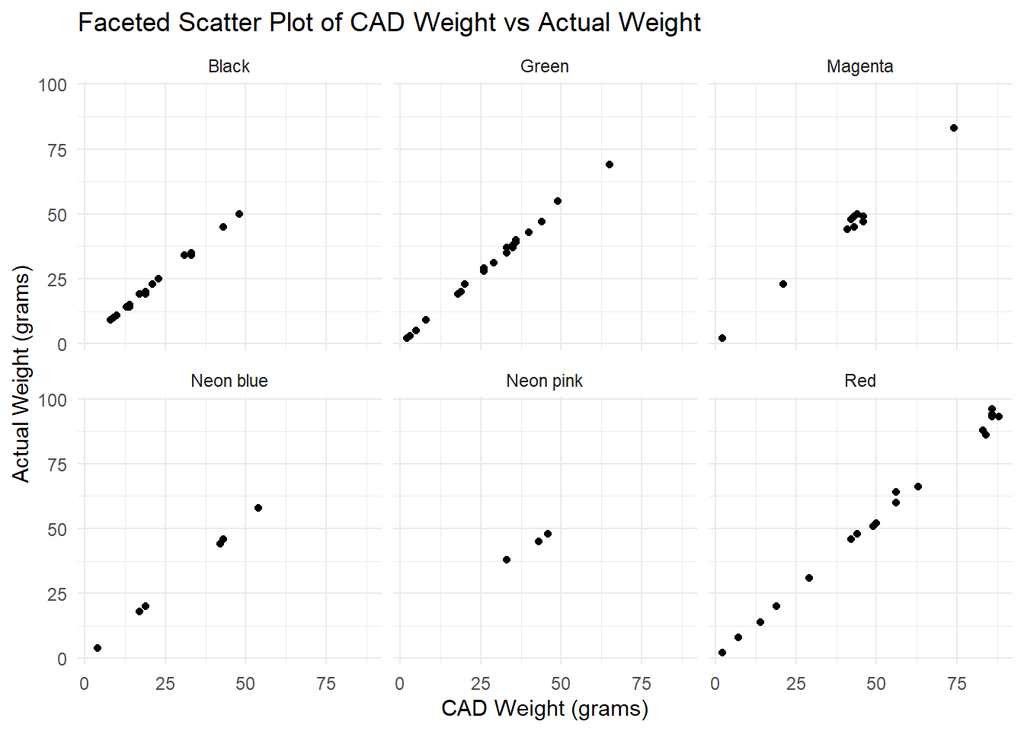

Firstly, I make a scatter plot between CAD Weight and Actual Weight among different materials since scatter plot is for observing the relationship between two continuous variables. However, since we are exploring the variability of the data for different “CAD_Weight” and “Material”, we just need to focus on the horizontal distribution of spots. Therefore, I will make a box plot with “Material” as horizontal axes and “CAD_Weight” as vertical axes.

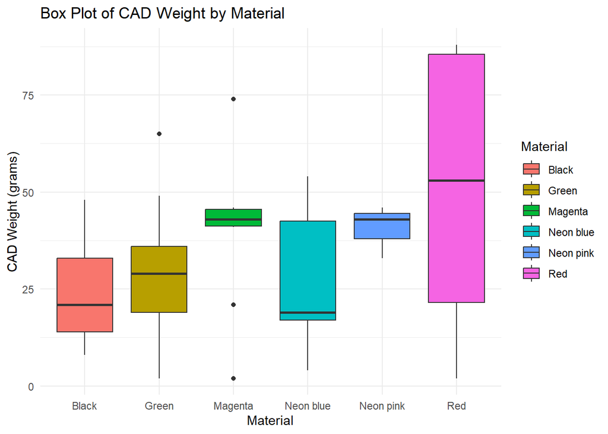

The provided box plot above displays the distribution of CAD weights for objects printed with different materials, with each box representing the interquartile range of weights for a specific material. It is obvious that the range of CAD weights varies significantly between materials. material with red color has a largest range on CAD weight and material neon pink has the smallest range on CAD weight. It is interesting that material with magenta color distributes mostly at from 40 to 45 but has some obvious outliers.

# 1 Classical estimation

In this part, we are going to make an classical estimation for two models, which capture the relationship between CAD_Weight and Actual_Weight. Here is the two models

Model A:
$$y_i \sim \text{Normal}(\beta_1
+ \beta_2 x_{i}, \exp(\beta_3 + \beta_4 x_{i}))$$

Model B:
$$y_i \sim \text{Normal}(\beta_1
+ \beta_2 x_{i}, \exp(\beta_3) + \exp(\beta_4) x_{i}^2)$$

We are going to use the following formula to find the negated log-likelihood function, then we estimate the parameters of two specified models (“A” or “B”) by minimizing the negative log-likelihood of the data given the model.

$$l(\beta)_{\text{negative}} =
-\log\left(\prod_{i=1}^{N} f(X_i; \beta)\right) = -\sum_{i=1}^{N}
\log(f(X_i; \beta))$$

After getting the parameters by optimization, we will calculates the variance for parameters by linear solving the negated hessian matrix, which is positively definite. Finally, we compute standard error from variance and find the z-value for the confidence interval (90% in this case). The output of the classical estimation of each parameter is displayed below, and there is a 90% confidence interval and standard error for each parameter.

90% Confidence Intervals for Model A

| Estimate | Lower | Upper | Std.Error |
| --- | --- | --- | --- |
| -0.0893297 | -0.3006372 | 0.1219777 | 0.1284658 |
| 1.0792092 | 1.0694709 | 1.0889476 | 0.0059205 |
| -1.9037802 | -2.4714169 | -1.3361435 | 0.3450986 |
| 0.0556949 | 0.0410248 | 0.0703649 | 0.0089188 |

90% Confidence Intervals for Model B

| Estimate | Lower | Upper | Std.Error |
| --- | --- | --- | --- |
| -0.1612845 | -0.2215253 | -0.1010437 | 0.0366238 |
| 1.0828591 | 1.0751616 | 1.0905566 | 0.0046798 |
| -13.5014797 | -98.0383477 | 71.0353883 | 51.3947664 |
| -6.6136018 | -6.8644413 | -6.3627623 | 0.1524996 |

From the table above, we can write our estimation for two models A and B.

Model A:

$$y_i \sim \text{Normal}(-0.0893 + 1.0792
x_{i}, \exp(-1.9038 + 0.0557 x_{i}))$$

Model B:

$$y_i \sim \text{Normal}(-0.1613 + 1.0829
x_{i}, \exp(-13.5015) + \exp(-6.6136) x_{i}^2)$$

Let me explain these four parameters in order:

$\beta_1$ is the intercept or the starting point of the actual weight. There’s some difference of $\beta_1$ for model A and model B, and $\beta_1$ of model B has smaller confidence interval because of the lower standard error.

$\beta_2$ is the parameter that shows the linear relationship between independent variable and response variable. For example, If we apply model A, a 1 gram increasing of CAD weight indicates that there will be a 1.0792 grams increasing of actual weight.

$\beta_3$ and $\beta_4$ are parameters that indicate the variance of the model. However, notice that the 90% confidence interval for $\beta_3$ in model B is extremely large. It may indicate that the model does not fit the data well. A model that does not capture the underlying structure of the data can lead to imprecise estimates of its parameters. In general, model A is simpler and gives outputs with fairly precise estimates, but it does not have motivation in physics. Model B is more complex and take the physical assumption that the error in the CAD software calculation of the weight is proportional to the weight itself. However, a paramater model B shows apparent uncertainty and large confidence interval.

# 2 Bayesian estimation

In this part, we are going to make a Bayesian approach for the bayesian model which describes the actual weight $y_i$ based on the CAD weight $x_i$ for observation i:

$y_i \sim \text{Normal}(\beta_1 + \beta_2 x_i + \beta_3 + \beta_4 x_i^2)$

To ensure positivity of the variance, the parameterisation $[\theta_1, \theta_2,\theta_3,\theta_4]$ = $[\beta_1, \beta_2, \log(\beta_3), \log(\beta_4)]$ is introduced, and the printer operator assigns independent prior distributions as follows:

$\theta_1 \sim {Normal}(0, \gamma_1)$

$\theta_2 \sim {Normal}(0, \gamma_2)$

$\theta_3 \sim {LogExp}(\gamma_3)$

$\theta_4 \sim {LogExp}(\gamma_4)$

where ${LogExp}(a)$ denotes the logarithm of an exponentially distributed random variable with rate parameter $a$. The $\gamma=(\gamma_1,\gamma_2,\gamma_3,\gamma_3)$ values are positive parameters.

Since the Bayesian approach considers $\theta$ to be a random variable, we need to define the prior distribution $p(\theta)$. Note that the observation vector $y$ does not intervene in $p(\theta)$. The prior distribution contains all available prior information about $\theta$ before observing any data. According to the Bayes’ theorem to obtain posterior distribution $p(\theta|y)$, which contains all available knowledge (prior information and data) about the quantity of interest $\theta$. The posterior distribution is computed as:

$p(\theta|y)=\frac{p(y|\theta)p(\theta)}{p(y)}$

In the Bayesian approach in our project, we compute the logarithm for both sides. In optimization problems, log transformations can turn multiplicative relationships into additive ones, which are often easier to handle. Another reason is that addition is computationally cheaper than multiplication. This can lead to more efficient algorithms and less error, especially in the context of optimization, where we often seek to maximize the likelihood or the posterior. This is the formula for posterior distribution after taking logarithm:

$\log(P(\theta|y)) \propto \log(P(y|\theta)) + \log(P(\theta))$

I define log_prior_density, log_like and log_posterior functions to compute the prior, observation and posterior distribution, using some pre-defined functions in code appendix. Then, we use posterior_mode function to evaluate the inverse of the negated Hessian at the mode, in order to obtain a multivariate Normal approximation ${Normal}(\mu,S)$ to the posterior distribution for $\theta$. Notice that we assume value for $\gamma_i$ is $(1,1,1,1)$, and the start value for $\theta_i$ is $(0,0,0,0)$. Here is the output:

```r
params <- rep(1, 4)

# Initial theta values
theta_start <- rep(0, 4)

# the data points
y <- filament1$Actual_Weight
x <- filament1$CAD_Weight

# Apply the posterior_mode function to find the mode and covariance matrix
post_mode_result <- posterior_mode(theta_start, x, y, params)

mu <- post_mode_result$mode
S <- solve(post_mode_result$hessian)

post_mode_result_df <- data.frame(
  Mode = post_mode_result$mode,
  Hessian_Diagonal = diag(post_mode_result$hessian),
  S_Diagonal = diag(post_mode_result$S)
)

knitr::kable(post_mode_result_df, caption = "Posterior Mode Results")
```

Posterior Mode Results

| Mode | Hessian_Diagonal | S_Diagonal |
| --- | --- | --- |
| -0.1008234 | 238.943762 | -0.0082952 |
| 1.0800211 | 63698.481091 | -0.0000300 |
| -2.9834581 | 1.464749 | -1.0664465 |
| -6.7584316 | 32.321593 | -0.0454331 |

```r
N <- 10000
importance_sample <- do_importance(N, mu, S, x = x, y = y, params = params)

sum(exp(importance_sample$log_weights))
```

```
## [1] 1
```

Since the do_importance functionoutput a data. frame with five columns, $\beta_1$, $\beta_2$, $\beta_3$, $\beta_4$, log_weights, containing the $\beta_i$ samples and normalised log importance weights, the sum of exp(log_weights) shoule be 1. we check our importance sample above.

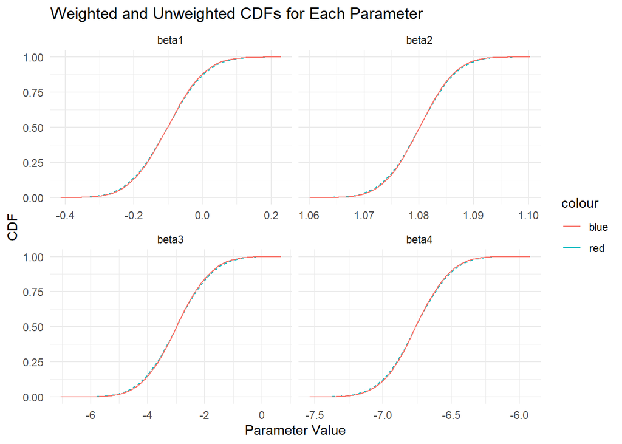

```r
# Construct the credible intervals
cred_int <- data.frame(t(sapply(1:4, function(i) {
  make_CI(importance_sample[[paste0("beta", i)]], importance_sample$log_weights, prob = 0.9)
})))

knitr::kable(cred_int, format = "html", caption = "90% Credible Intervals for Model Parameters")
```

90% Credible Intervals for Model Parameters

| lower | upper |
| --- | --- |
| -0.2435664 | 0.03963397 |
| 1.07151 | 1.088663 |
| -4.583301 | -1.360347 |
| -7.094913 | -6.422283 |

This is the 90% credible interval of parameters for our Bayesian model based on the importance sample. In addition to wquantile and pivot_longer, the methods group_by and summarise are helpful. You may wish to define a function make_CI taking arguments x, weights, and prob (to control the intended coverage probability). All the confidence intervals for the four model parameters are acceptable compared with that of model B of classical estimation. There is not any confidence intervals with extremely large range which shows uncertainty of the model.

[figure not shown]

A prediction interval is an estimate of an interval within which future observations will fall, with a certain probability. It is calculated from the sampled beta values, which represent the parameters of the model. The sampled beta values are used to generate predicted values, and the variability in these predictions forms the basis of the prediction interval. The prediction interval includes not only the uncertainty of the parameter estimates but also the inherent randomness in the data.

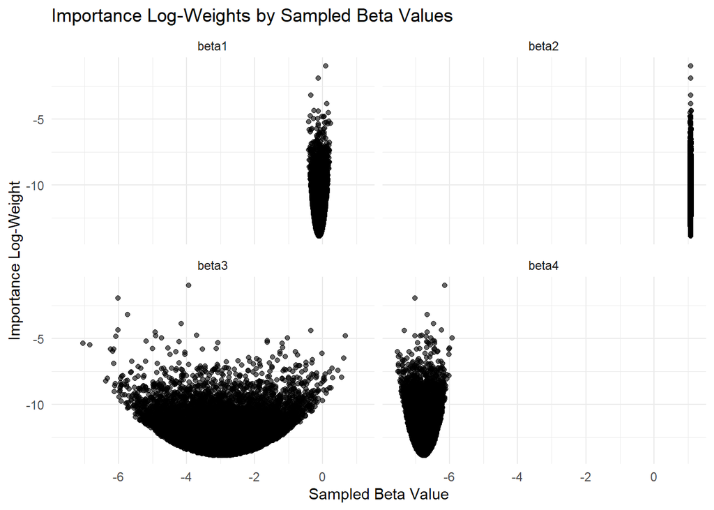

The plots suggests our estimation and confidence interval. In Bayesian statistics, importance sampling is used to approximate posterior distributions or expectation. The importance weights are calculated based on how the sampled beta values relate to the posterior distribution. These weights are then used to adjust the estimates to more accurately reflect the target distribution. Therefore, the sampled beta values directly affect the importance weights, and consequently, any estimates or intervals calculated from the importance sampling process.

# 3 Code appendix

```r
#' Boshu Jiang, s2196886
#' Add your own function definitions on this file.

#' Log-Exponential density
#'
#' Compute the density or log-density for a Log-Exponential (LogExp)
#' distribution
#'
#' @param x vector of quantiles
#' @param rate vector of rates
#' @param log logical; if TRUE, the log-density is returned

dlogexp <- function(x, rate = 1, log = FALSE) {
  result <- log(rate) + x - rate * exp(x)
  if (!log) {
    exp(result)
  }
  result
}

#' Log-Sum-Exp
#'
#' Convenience function for computing log(sum(exp(x))) in a
#' numerically stable manner
#'
#' @param x numerical vector

log_sum_exp <- function(x) {
  max_x <- max(x, na.rm = TRUE)
  max_x + log(sum(exp(x - max_x)))
}


#' wquantile
#'
#' Calculates empirical sample quantiles with optional weights, for given probabilities.
#' Like in quantile(), the smallest observation corresponds to a probability of 0 and the largest to a probability of 1.
#' Interpolation between discrete values is done when type=7, as in quantile().
#' Use type=1 to only generate quantile values from the raw input samples.
#'
#' @param x numeric vector whose sample quantiles are wanted
#' NA and NaN values are not allowed in numeric vectors unless na.rm is TRUE
#' @param probs numeric vector of probabilities with values in [0,1]
#' @param na.rm logical; if true, any NA and NaN's are removed from x before the quantiles are computed
#' @param type numeric, 1 for no interpolation, or 7, for interpolated quantiles. Default is 7
#' @param weights    numeric vector of non-negative weights, the same length as x, or NULL. The weights are normalised to sum to 1. If NULL, then wquantile(x) behaves the same as quantile(x), with equal weight for each sample value

wquantile <- function (x, probs = seq(0, 1, 0.25), na.rm = FALSE, type = 7,
                       weights = NULL, ...)
{
  if (is.null(weights) || (length(weights) == 1)) {
    weights <- rep(1, length(x))
  }
  stopifnot(all(weights >= 0))
  stopifnot(length(weights) == length(x))
  if (length(x) == 1) {
    return(rep(x, length(probs)))
  }
  n <- length(x)
  q <- numeric(length(probs))
  reorder <- order(x)
  weights <- weights[reorder]
  x <- x[reorder]
  wecdf <- pmin(1, cumsum(weights)/sum(weights))
  if (type == 1) {
  }
  else {
    weights2 <- (weights[-n] + weights[-1])/2
    wecdf2 <- pmin(1, cumsum(weights2)/sum(weights2))
  }
  for (pr_idx in seq_along(probs)) {
    pr <- probs[pr_idx]
    if (pr <= 0) {
      q[pr_idx] <- x[1]
    }
    else if (pr >= 1) {
      q[pr_idx] <- x[n]
    }
    else {
      if (type == 1) {
        j <- 1 + pmax(0, pmin(n - 1, sum(wecdf <= pr)))
        q[pr_idx] <- x[j]
      }
      else {
        j <- 1 + pmax(0, pmin(n - 2, sum(wecdf2 <= pr)))
        g <- (pr - c(0, wecdf2)[j])/(wecdf2[j] - c(0,
                                                   wecdf2)[j])
        q[pr_idx] <- (1 - g) * x[j] + g * x[j + 1]
      }
    }
  }
  q
}

#' Compute empirical weighted cumulative distribution
#'
#' Version of `ggplot2::stat_ecdf` that adds a `weights` property for each
#' observation, to produce an empirical weighted cumulative distribution function.
#' The empirical cumulative distribution function (ECDF) provides an alternative
#' visualisation of distribution. Compared to other visualisations that rely on
#' density (like [geom_histogram()]), the ECDF doesn't require any
#' tuning parameters and handles both continuous and discrete variables.
#' The downside is that it requires more training to accurately interpret,
#' and the underlying visual tasks are somewhat more challenging.
#'
# @inheritParams layer
# @inheritParams geom_point
#' @param na.rm If `FALSE` (the default), removes missing values with
#'    a warning.  If `TRUE` silently removes missing values.
#' @param n if NULL, do not interpolate. If not NULL, this is the number
#'   of points to interpolate with.
#' @param pad If `TRUE`, pad the ecdf with additional points (-Inf, 0)
#'   and (Inf, 1)
#' @section Computed variables:
#' \describe{
#'   \item{x}{x in data}
#'   \item{y}{cumulative density corresponding x}
#' }
#' @seealso wquantile
#' @export
#' @examples
#' library(ggplot2)
#'
#' n <- 100
#' df <- data.frame(
#'   x = c(rnorm(n, 0, 10), rnorm(n, 0, 10)),
#'   g = gl(2, n),
#'   w = c(rep(1/n, n), sort(runif(n))^sqrt(n))
#' )
#' ggplot(df, aes(x, weights = w)) + stat_ewcdf(geom = "step")
#'
#' # Don't go to positive/negative infinity
#' ggplot(df, aes(x, weights = w)) + stat_ewcdf(geom = "step", pad = FALSE)
#'
#' # Multiple ECDFs
#' ggplot(df, aes(x, colour = g, weights = w)) + stat_ewcdf()
#' ggplot(df, aes(x, colour = g, weights = w)) +
#'   stat_ewcdf() +
#'   facet_wrap(vars(g), ncol = 1)

stat_ewcdf <- function(mapping = NULL, data = NULL,
                       geom = "step", position = "identity",
                       ...,
                       n = NULL,
                       pad = TRUE,
                       na.rm = FALSE,
                       show.legend = NA,
                       inherit.aes = TRUE) {
  ggplot2::layer(
    data = data,
    mapping = mapping,
    stat = StatEwcdf,
    geom = geom,
    position = position,
    show.legend = show.legend,
    inherit.aes = inherit.aes,
    params = list(
      n = n,
      pad = pad,
      na.rm = na.rm,
      ...
    )
  )
}


#' @title StatEwcdf ggproto object
#' @name StatEwcdf
#' @rdname StatEwcdf
#' @aliases StatEwcdf
#' @format NULL
#' @usage NULL
#' @export
#' @importFrom ggplot2 aes after_stat has_flipped_aes Stat
NULL

StatEwcdf <- ggplot2::ggproto(
  "StatEwcdf", ggplot2::Stat,
  required_aes = c("x|y", "weights"),
  dropped_aes = c("weights"),

  default_aes = ggplot2::aes(y = ggplot2::after_stat(y)),

  setup_params = function(data, params) {
    params$flipped_aes <-
      ggplot2::has_flipped_aes(data,
                               params,
                               main_is_orthogonal = FALSE,
                               main_is_continuous = TRUE)

    has_x <- !(is.null(data$x) && is.null(params$x))
    has_y <- !(is.null(data$y) && is.null(params$y))
    if (!has_x && !has_y) {
      rlang::abort("stat_ewcdf() requires an x or y aesthetic.")
    }
    has_weights <- !(is.null(data$weights) && is.null(params$weights))
    #    if (!has_weights) {
    #      rlang::abort("stat_ewcdf() requires a weights aesthetic.")
    #    }
```

```r
    params
  },

  compute_group = function(data, scales, n = NULL, pad = TRUE, flipped_aes = FALSE) {
    data <- flip_data(data, flipped_aes)
    # If n is NULL, use raw values; otherwise interpolate
    if (is.null(n)) {
      x <- unique(data$x)
    } else {
      x <- seq(min(data$x), max(data$x), length.out = n)
    }

    if (pad) {
      x <- c(-Inf, x, Inf)
    }
    if (is.null(data$weights)) {
      data_ecdf <- ecdf(data$x)(x)
    } else {
      data_ecdf <-
        spatstat.geom::ewcdf(
          data$x,
          weights = data$weights / sum(abs(data$weights))
        )(x)
    }

    df_ecdf <- vctrs::new_data_frame(list(x = x, y = data_ecdf), n = length(x))
    df_ecdf$flipped_aes <- flipped_aes
    ggplot2::flip_data(df_ecdf, flipped_aes)
  }
)

load("filament1.rda")
library(styler)
library(ggplot2)
library(dplyr)

#' neg_log_like
#'
#' compute the negative log-likelihood for a given set of parameters,
#' data, and model specification.
#'
#' @param beta These parameters are used to define the mean and standard deviation
#' of the normal distribution that models the relationship between the predictor(s)
#' and the response variable.
#' @param data data frame containing the observed data, including CAD_Weight and Actual Weight
#' @param model A character string that specifies the model to be used,including "A" and "B",

neg_log_like <- function(beta, data, model) {
  x <- data$CAD_Weight
  y <- data$Actual_Weight

  if (model == "A") {
    mu <- beta[1] + beta[2] * x
    sigma <- exp(beta[3] + beta[4] * x)
  } else if (model == "B") {
    mu <- beta[1] + beta[2] * x
    sigma <- exp(beta[3]) + exp(beta[4]) * x^2
  }

  neg_log_likelihood <- -sum(dnorm(y, mean = mu, sd = sqrt(sigma), log = TRUE))
  return(neg_log_likelihood)
}

#' filament1_estimate
#'
#'  estimate the parameters of two specified models ("A" or "B")
#'  by minimizing the negative log-likelihood of the data given the model.
#'
#' @param data containing the observed values, including
#' the variables used by the neg_log_like function, which are CAD_Weight
#' and Actual_Weight.
#' @param model A character string that specifies the model to be used,
#' including "A" and "B", each model with a different initial value for optimization.

filament1_estimate <- function(data, model) {
  if (model == "A") {
    init_values <- c(-0.1, 1.07, -2, 0.05)
  } else if (model == "B") {
    init_values <- c(-0.15, 1.07, -13.5, -6.5)
  }

  optim_res <- optim(par = init_values, fn = neg_log_like, data = data, model = model, hessian = TRUE, method = "BFGS")

  return(list(estimate = optim_res$par, hessian = optim_res$hessian))
}

#' compute_CI
#'
#' It leverages the Hessian matrix obtained during optimization to
#' compute the standard errors of the parameter estimates, which are then
#' used to construct the 90% confidence intervals for model estimator returned
#' by filament1_estimate function
#'
#' @param fit A list containing at least two components, which are estimate and
#' hessian. Estimate is the vector of parameter estimates obtained from the optimization.
#' Hessian is the hessian matrix at the optimal parameters.

compute_CI <- function(fit) {
  se <- sqrt(diag(solve(fit$hessian)))

  # Z value for 90% confidence interval
  z_value <- qnorm(0.95)

  # Calculate the confidence intervals
  lower_bound <- fit$estimate - z_value * se
  upper_bound <- fit$estimate + z_value * se

  return(data.frame(Estimate = fit$estimate, Lower = lower_bound, Upper = upper_bound, Std.Error = se))
}

#' log_prior_density
#'
#' calculate the logarithm of the joint prior density of the parameters theta.
#' @param theta a numeric vector representing the parameters theta_1 to theta_4
#' @param params another numeric vector representing the gamma parameters from
#' gamma_1 to gamma_4

log_prior_density <- function(theta, params) {
  # Extract the parameters
  gamma1 <- params[1]
  gamma2 <- params[2]
  gamma3 <- params[3]
  gamma4 <- params[4]

  # Calculate the log prior density for each parameter
  log_prior_theta1 <- dnorm(theta[1], mean = 0, sd = sqrt(gamma1), log = TRUE)
  log_prior_theta2 <- dnorm(theta[2], mean = 1, sd = sqrt(gamma2), log = TRUE)
  log_prior_theta3 <- dlogexp(theta[3], rate = gamma3, log = TRUE)
  log_prior_theta4 <- dlogexp(theta[4], rate = gamma4, log = TRUE)

  # Sum the log priors to get the joint log prior density
  log_joint_prior <- log_prior_theta1 + log_prior_theta2 + log_prior_theta3 + log_prior_theta4

  return(log_joint_prior)
}

#' log_like
#'
#' evaluate the observation log-likelihood p(y|theta) for a specified model,
#' taking into account the parameters theta and data points x and y
#' @param theta a numeric vector representing the parameters theta_1 to theta_4
#' @param x the independent variable
#' @param y the response variable

log_like <- function(theta, x, y) {
  beta1 <- theta[1]
  beta2 <- theta[2]
  beta3 <- exp(theta[3])
  beta4 <- exp(theta[4])

  mu <- beta1 + beta2 * x
  sigma <- beta3 + beta4 * x^2

  # Compute the log-likelihood for each observation
  log_lik_vector <- dnorm(y, mean = mu, sd = sqrt(sigma), log = TRUE)

  sum_log_lik <- sum(log_lik_vector)
  return(sum_log_lik)
}

#' log_posterior_density
#'
#' evaluates the logarithm of the posterior density p(theta|y)
#' @param theta a numeric vector representing the parameters theta_1 to theta_4
#' @param x the independent variable
#' @param y the response variable

log_posterior_density <- function(theta, x, y, params) {
  # Compute the log-likelihood
  log_lik <- log_like(theta, x, y)

  # Compute the log-prior density
  log_prior <- log_prior_density(theta, params)

  # The log-posterior is the sum of the log-likelihood and log-prior
  log_post <- log_lik + log_prior

  return(log_post)
}

#' posterior_mode
#'
#' find the mode of the posterior distribution for a set of parameters and calculate the precision of these estimates.
#' It uses numerical optimization to maximize the log-posterior density, which is equivalent to minimizing
#' the negative log-posterior density due to the symmetry of optimization.
#'
#' @param theta_start A numeric vector representing the starting values for the parameters
#' @param x The independent variable CAD_Weight in filament1.
#' @param y The response variable Actual_Weight in filament1.
#' @param params A vector of additional parameters that are needed for calculating the log-posterior density.
```

```r
posterior_mode <- function(theta_start, x, y, params) {
  neg_log_posterior <- function(theta) -log_posterior_density(theta, x, y, params)

  # Use optim to maximize the log-posterior density
  optim_result <- optim(theta_start, neg_log_posterior, method = "BFGS", hessian = TRUE)

  # Compute the inverse of the negated Hessian
  S <- solve(-optim_result$hessian)

  # Return a list with mode, Hessian, and S
  return(list(mode = optim_result$par, hessian = optim_result$hessian, S = S))
}

#' do_importance
#'
#' @param N The number of samples to generate.
#' @param mu The mean vector of the multivariate normal distribution used as the importance distribution.
#' @param S he covariance matrix of the multivariate normal distribution used as the importance distribution.

do_importance <- function(N, mu, S, ...) {
  # Sample from the multivariate normal distribution
  samples <- mvtnorm::rmvnorm(N, mean = mu, sigma = S)

  # Calculate the log-likelihoods of these samples using dmvnorm
  log_densities <- mvtnorm::dmvnorm(samples, mean = mu, sigma = S, log = TRUE)

  # Calculate log_weights (importance weights)
  log_weights <- -log_densities

  # Normalize log_weights
  max_log_weight <- max(log_weights)
  log_weights <- log_weights - (max_log_weight + log(sum(exp(log_weights - max_log_weight))))

  # Create the data.frame
  results <- data.frame(beta1 = samples[,1], beta2 = samples[,2],
                        beta3 = samples[,3], beta4 = samples[,4],
                        log_weights = log_weights)
  return(results)
}

#' make_CI
#'
#' calculates a weighted credible interval for a set of data points x using the
#' corresponding weights and the specified probability for the coverage of the interval.
#'
#' @param x A numeric vector of data points for which the credible interval is to be calculated.
#' @param weights A numeric vector of weights associated with the data points in x
#' @param prob The probability coverage for the credible interval

make_CI <- function(x, weights, prob) {
  normalized_weights <- weights / sum(weights)
  # Calculate the lower and upper bounds of the credible interval
  CI_bounds <- wquantile(x, probs = c((1 - prob) / 2, 1 - (1 - prob) / 2),
                         na.rm = TRUE, type = 1, weights = normalized_weights)

  # Return the credible interval as a data frame
  data.frame(lower = CI_bounds[1], upper = CI_bounds[2])
}
```